# R Notebook

This is my first Kaggle competition, I thought it would be interesting to pick a marketing/sales related dataset to work with. I’m choosing to work in R for this assignment, if only because I’m more comfortable in Python and I’m trying to expand my language capabilities. Let’s perform some initial exploratory analysis/pre-processing.

# Pre-Processing

```r
#Read in training and test sets
train<-read_csv('train.csv')
test<-read_csv('test.csv')
print(dim(train))
```

```
[1] 1460   81
```

```r
print(dim(test))
```

```
[1] 1459   80
```

```r
head(train)
```

| Id | MSSubClass | MSZoning | LotFrontage | LotArea | Street | Alley | LotShape | LandContour | Utilities | LotConfig | LandSlope | Neighborhood | Condition1 | Condition2 | BldgType | HouseStyle | OverallQual | OverallCond | YearBuilt | YearRemodAdd | RoofStyle | RoofMatl | Exterior1st | Exterior2nd | MasVnrType | MasVnrArea | ExterQual | ExterCond | Foundation | … |
| --- | --- | --- | --- | --- | --- | --- | --- | --- | --- | --- | --- | --- | --- | --- | --- | --- | --- | --- | --- | --- | --- | --- | --- | --- | --- | --- | --- | --- | --- | --- |
| 1 | 60 | RL | 65 | 8450 | Pave | NA | Reg | Lvl | AllPub | Inside | Gtl | CollgCr | Norm | Norm | 1Fam | 2Story | 7 | 5 | 2003 | 2003 | Gable | CompShg | VinylSd | VinylSd | BrkFace | 196 | Gd | TA | PConc | … |
| 2 | 20 | RL | 80 | 9600 | Pave | NA | Reg | Lvl | AllPub | FR2 | Gtl | Veenker | Feedr | Norm | 1Fam | 1Story | 6 | 8 | 1976 | 1976 | Gable | CompShg | MetalSd | MetalSd | None | 0 | TA | TA | CBlock | … |
| 3 | 60 | RL | 68 | 11250 | Pave | NA | IR1 | Lvl | AllPub | Inside | Gtl | CollgCr | Norm | Norm | 1Fam | 2Story | 7 | 5 | 2001 | 2002 | Gable | CompShg | VinylSd | VinylSd | BrkFace | 162 | Gd | TA | PConc | … |
| 4 | 70 | RL | 60 | 9550 | Pave | NA | IR1 | Lvl | AllPub | Corner | Gtl | Crawfor | Norm | Norm | 1Fam | 2Story | 7 | 5 | 1915 | 1970 | Gable | CompShg | Wd Sdng | Wd Shng | None | 0 | TA | TA | BrkTil | … |
| 5 | 60 | RL | 84 | 14260 | Pave | NA | IR1 | Lvl | AllPub | FR2 | Gtl | NoRidge | Norm | Norm | 1Fam | 2Story | 8 | 5 | 2000 | 2000 | Gable | CompShg | VinylSd | VinylSd | BrkFace | 350 | Gd | TA | PConc | … |
| 6 | 50 | RL | 85 | 14115 | Pave | NA | IR1 | Lvl | AllPub | Inside | Gtl | Mitchel | Norm | Norm | 1Fam | 1.5Fin | 5 | 5 | 1993 | 1995 | Gable | CompShg | VinylSd | VinylSd | None | 0 | TA | TA | Wood | … |

There are 81 columns in this dataset with 1460 total rows. Because of the size, let’s take a look at some descriptive statistics, including missing values.

```r
sprintf('There are %s missing values', sum(is.na(train)))
```

```
[1] "There are 6965 missing values"
```

```r
mis_vals <- sort(sapply(train, function(x) sum(is.na(x))), decreasing= T)[1:19]

as.data.frame(mis_vals)
```

|  | mis_vals |
| --- | --- |
| PoolQC | 1453 |
| MiscFeature | 1406 |
| Alley | 1369 |
| Fence | 1179 |
| FireplaceQu | 690 |
| LotFrontage | 259 |
| GarageType | 81 |
| GarageYrBlt | 81 |
| GarageFinish | 81 |
| GarageQual | 81 |

[output cut: 9 more lines]

It seems that the majority of missing values associated with qualitative measures referring to housing characteristics. There is a great package to deal with missing values, Amelia, which uses multiple imputation. First though, we’ll add labels to the character columns, and check for collinear variables.

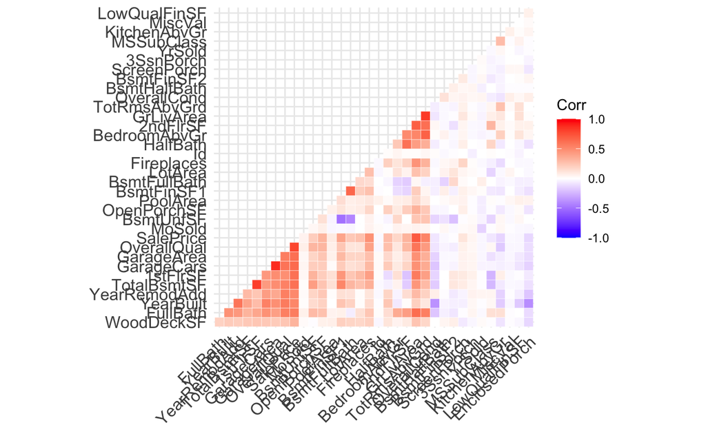

```r
#Select numeric for correlation matrix
num_cols<-train[,sapply(train, class)=='numeric']
num_cols<-num_cols[!names(num_cols)%in% c('LotFrontage', 'GarageYrBlt', 'MasVnrArea')] #exclude columns with missing

library(CatEncoders)
char <- train[,sapply(train, class)=='character'] #Get character columns
char_names<-names(char)
for(col in char_names){ #convert characters to numeric
    lab<-LabelEncoder.fit(unique(na.omit(train[[col]])))
    train[col]<-transform(lab,train[[col]])
    test[col]<-transform(lab, test[[col]])
}


cor_matrix <- round(cor(num_cols),2)
library(ggcorrplot)
ggcorrplot(cor_matrix, hc.order = T, type = 'lower', outline.col='white')
```

```r
tmp <- cor(train)
tmp[upper.tri(tmp)] <- 0
diag(tmp) <- 0
train <- train[, !apply(tmp, 2, function(x) any(abs(x) > 0.75
                                                , na.rm = TRUE))] #remove correlated columns
train<-train[!names(train)%in%"Utilities"]
test<-test[names(test)%in%names(train)] #Keep Train columns

col_inds <- array(match(names(mis_vals), colnames(train))) #index columns with missing values
mis_df <- as.data.frame(t(train[names(mis_vals)])) #generate transposed dataframe of missing values
min_arr <- array(apply(mis_df, 1, FUN=min, na.rm=T)) #get min/max vals for imputation bounding
max_arr <- array(apply(mis_df, 1, FUN=max, na.rm=T))
bounds <- cbind(col_inds, min_arr, max_arr)
```

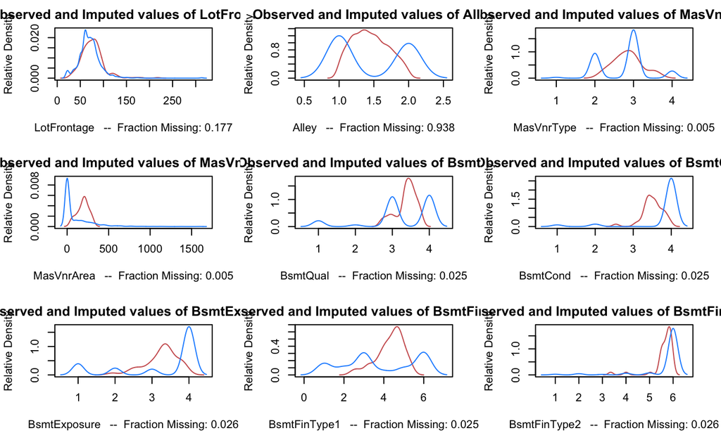

```r
#Multiple imputation
a_out<- amelia(as.data.frame(train), p2s=0, bounds= bounds)

plot(a_out)
```

[figure not shown]

[figure not shown]

```r
NA
```

```r
a_out_test<-amelia(as.data.frame(test), p2s=0, bounds= bounds, empiri = .05*length(test))
plot(a_out_test)
```

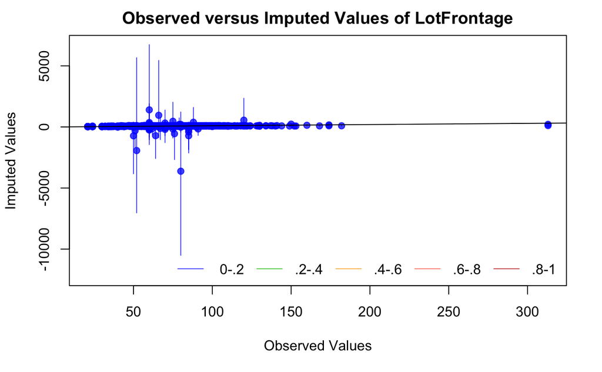

```r
train<-a_out$imputations$imp5
test<- a_out_test$imputations$imp5
overimpute(a_out, 'LotFrontage')
```

```r
set.seed(101) # Set Seed so that same sample can be reproduced in future also
# Now Selecting 75% of data as sample from total 'n' rows of the data
sample <- sample.int(n = nrow(train), size = floor(.75*nrow(train)), replace = F)
train_new <- train[sample, ]
test_new  <- train[-sample, ]
X_train <- as.matrix(train[!names(train_new)%in%'SalePrice'])
y_train <- as.matrix(train[names(train_new)%in%'SalePrice'])
X_test <- as.matrix(train[!names(test_new)%in%'SalePrice'])
y_test <- as.matrix(train[names(test_new)%in%'SalePrice'])

library(xgboost)
d_matrix <- xgb.DMatrix(data = X_train, label = y_train)
test_matrix<- xgb.DMatrix(data = X_test, label = y_test)

xgbc = xgboost(data = d_matrix, max.depth = 9, nrounds = 250)
print(xgbc)
```

```
##### xgb.Booster
raw: 3 Mb
call:
  xgb.train(params = params, data = dtrain, nrounds = nrounds,
    watchlist = watchlist, verbose = verbose, print_every_n = print_every_n,
    early_stopping_rounds = early_stopping_rounds, maximize = maximize,
    save_period = save_period, save_name = save_name, xgb_model = xgb_model,
    callbacks = callbacks, max.depth = 9)
params (as set within xgb.train):
  max_depth = "9", validate_parameters = "1"
xgb.attributes:
  niter
callbacks:
  cb.print.evaluation(period = print_every_n)
  cb.evaluation.log()
# of features: 74
niter: 250
nfeatures : 74
evaluation_log:
```

| iter | train_rmse |
| --- | --- |
| 1 | 1.418437e+05 |
| 2 | 1.025798e+05 |
| 3 | 7.491377e+04 |
| 4 | 5.522252e+04 |
| 5 | 4.104001e+04 |
| 6 | 3.074217e+04 |
| 7 | 2.337274e+04 |
| 8 | 1.809332e+04 |
| 9 | 1.419887e+04 |
| 10 | 1.144822e+04 |

[output cut: 240 more lines]

```r
pred_y = predict(xgbc, test_matrix)

mse = mean((y_test - pred_y)^2)
mae = caret::MAE(y_test, pred_y)
rmse = caret::RMSE(y_test, pred_y)

cat("MSE: ", mse, "MAE: ", mae, " RMSE: ", rmse)
```

```
MSE:  0.0006781069 MAE:  0.01836205  RMSE:  0.02604048
```

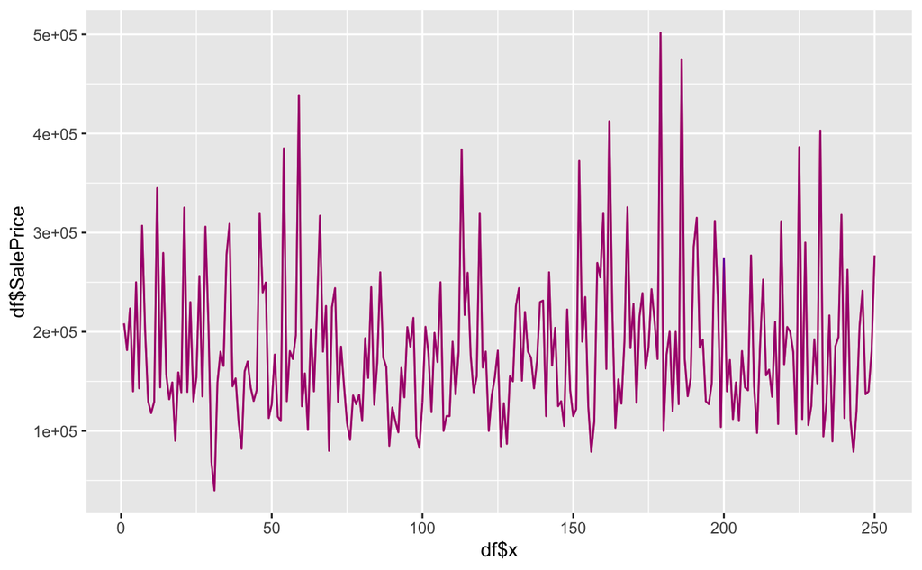

```r
x = 1:length(y_test)
df<-as.data.frame(cbind(x, y_test, pred_y))
df<-df[1:250,]
ggplot(data=df, aes(x = df$x))+
  geom_line(aes(y= df$SalePrice), color = 'red')+
  geom_line(aes(y=df$pred_y), color = 'blue', alpha = 0.4)
```

```r
test_matrix<- xgb.DMatrix(as.matrix(test))
predictions = data.frame('Id'=test$Id, 'SalePrice'=predict(xgbc, test_matrix))
write_csv(predictions, 'submission.csv')
head(predictions)
```

|  | Id | SalePrice |
| --- | --- | --- |
| 1 | 1461 | 144026.2 |
| 2 | 1462 | 158718.2 |
| 3 | 1463 | 183100.8 |
| 4 | 1464 | 164768.8 |
| 5 | 1465 | 183366.3 |
| 6 | 1466 | 185837.0 |

My predictions obtained a RMSLE of .17226.